# School Segregation Ecological Analysis

Author

Mateo Frumholtz

Published

November 8, 2024

**Segregation Metrics**

Unless otherwise noted, the segregation metric used across most of these analysis is the Normalized Exposure Index. Refer to the School Segregation Index Descriptive Report tab for more information on the various indices.

# Ecological Correlation Matrices

## Metro Elementary Schools

**Note**

The correlation matrix below shows elementary schools in the Twin Cities metro area with at least 50 students. Some of the PELSB measures are not available in 2003 so they were removed from the analysis for those years.

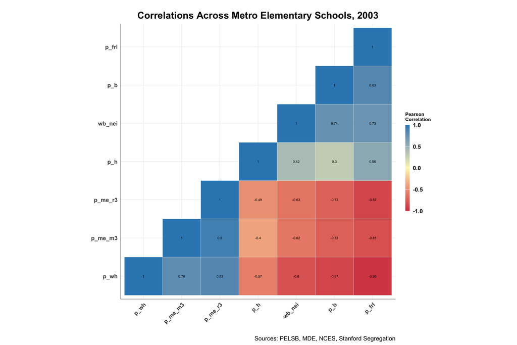

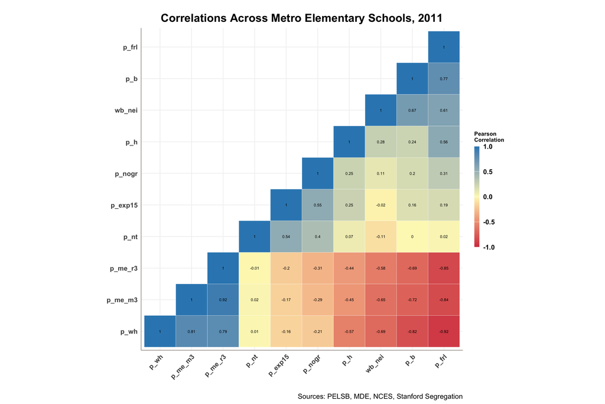

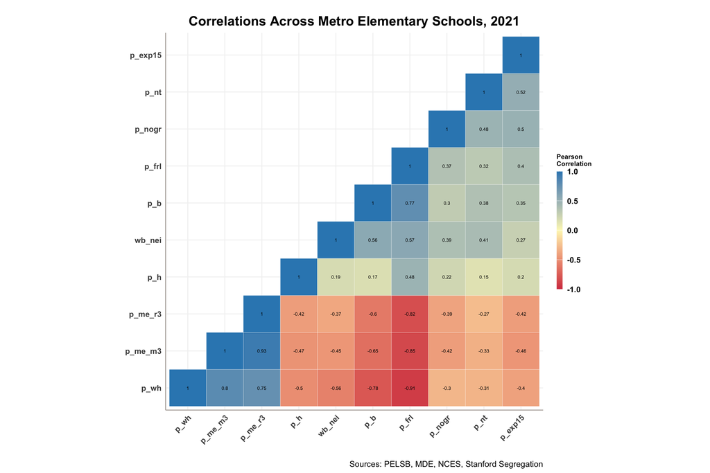

## Metro Middle Schools

**Note**

The correlation matrix below shows middle schools in the Twin Cities metro area with at least 50 students. Some of the PELSB measures are not available in 2003 so they were removed from the analysis for those years.

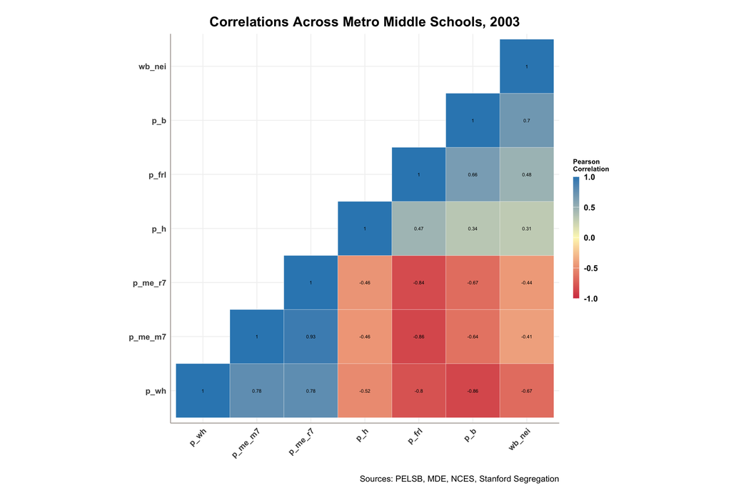

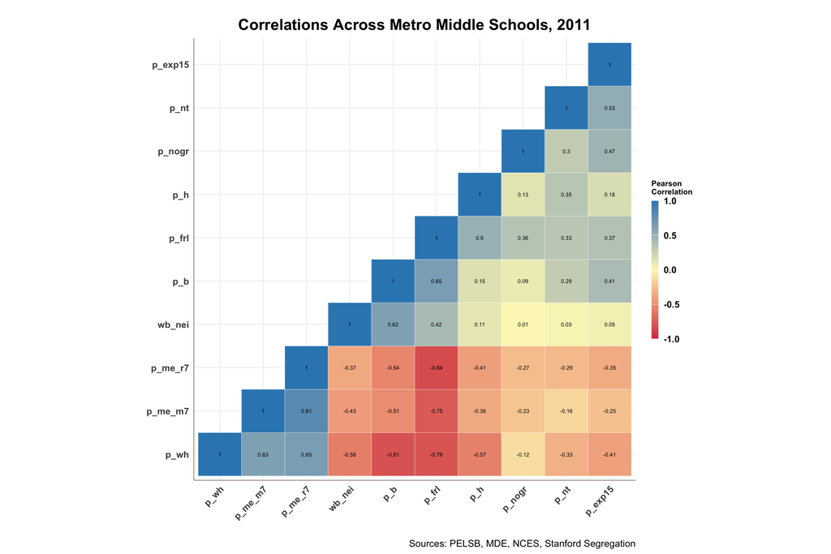

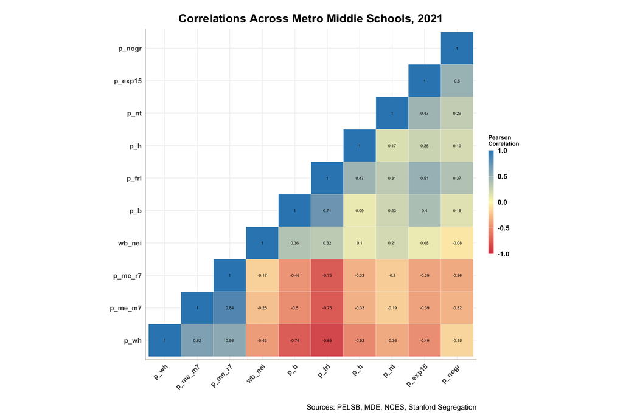